# DCA_DataFrames

Ben J. Rivera

2023-01-16

The goal of this script is to create and clean the necessary dataframes to be used in analysis later. Run this first then move on to other scripts.

# Reading CSVs in

Okay, this is the boring part. I need to just load in all my datasets and get everything nice and pretty. I’m going to have to deal with plant names.

## Places

Loading in data based on where it was collected

```r
Proper_Names <- read_csv(here("EnteredData", "PlantNameChanger.csv"))
# Ten Mile
TeMi_Coords <- read_csv(here("EnteredData", "TeMi_RelativeCoords.csv"))
TeMi_Dist <- read_csv(here("EnteredData", "TeMi_Distance.csv"))
TeMi_Locations <- read_csv(here("EnteredData", "TeMi_Location.csv"))
# Zmudowski
Zmud_Coords <- read_csv(here("EnteredData", "Zmud_RelativeCoords.csv"))
Zmud_Dist <- read_csv(here("EnteredData", "Zmud_Distance.csv"))
Zmud_Locations <- read_csv(here("EnteredData", "ZmudLocations.csv"))
# Guadalupe Nipomo
GuNi_Coords <- read_csv(here("EnteredData", "GuNi_RelativeCoords.csv"))
GuNi_Dist <- read_csv(here("EnteredData", "GuNi_Distance.csv"))
GuNi_Locations <- read_csv(here("EnteredData", "GuNi_Location.csv"))
```

### Fixing Cover Names

```r
TeMi_Cover <- read_csv(here("EnteredData", "TeMi_Cover.csv"))
TeMi_Cover<- merge(TeMi_Cover, Proper_Names, by.x = "Species", by.y = "Old_Species_Name")
rownames(TeMi_Cover)<- TeMi_Cover$New_Species_Name
TeMi_Cover<- TeMi_Cover[2:(length(TeMi_Cover)-1) ]

Zmud_Cover <- read_csv(here("EnteredData", "Zmud_Cover.csv"))
Zmud_Cover<- merge(Zmud_Cover, Proper_Names, by.x = "Species", by.y = "Old_Species_Name")
rownames(Zmud_Cover)<- Zmud_Cover$New_Species_Name
Zmud_Cover<- Zmud_Cover[2:(length(Zmud_Cover)-1) ]

GuNi_Cover <- read_csv(here("EnteredData", "GuNi_Cover.csv"))
GuNi_Cover<- merge(GuNi_Cover, Proper_Names, by.x = "Species", by.y = "Old_Species_Name")
rownames(GuNi_Cover)<- GuNi_Cover$New_Species_Name
GuNi_Cover<- GuNi_Cover[2:(length(GuNi_Cover)-1) ]
```

### Create Relative Coords

Here I am creating coordinates for each point at each site relative to the plot. Rather than being absolute, North South, these are positioned parrelel to the waterline. This will be used for drawing environmental comparisons along these axes which make more sense with stress.

```r
#TeMi
TeMi_Subset_X <- subset(TeMi_Coords, IN_FID == 1) #Just the X
TeMi_Subset_Y <- subset(TeMi_Coords, IN_FID == 2) #Just the Y
TeMi_Sub<-merge(TeMi_Subset_X, TeMi_Subset_Y, by = "NEAR_FID") #recombine them
TeMi_RelCords<- data.frame(Plot= TeMi_Sub$NEAR_FID, X = TeMi_Sub$NEAR_DIST.x, Y = TeMi_Sub$NEAR_DIST.y, Z = TeMi_Locations$POINT_Z) #make a data frame with XYZ
TeMi_RelCords$Plot<- merge(TeMi_RelCords[1], TeMi_Locations[1:2], by.x = "Plot", by.y = "OID_")$Comment #This fixes the names
TeMi_RelCords<- mutate(TeMi_RelCords, X = ifelse(TeMi_RelCords$Plot == "WATERLINE",-1*X, X)) #
TeMi_RelCords$Z <- TeMi_RelCords$Z - min(subset(TeMi_RelCords,Plot != "WATERLINE")$Z)

#Zmud
Zmud_Subset_X <- subset(Zmud_Coords, IN_FID == 2)
Zmud_Subset_Y <- subset(Zmud_Coords, IN_FID == 3)
Zmud_Sub<-merge(Zmud_Subset_X, Zmud_Subset_Y, by = "NEAR_FID")
Zmud_RelCords<- data.frame(Plot= Zmud_Sub$NEAR_FID, X = Zmud_Sub$NEAR_DIST.x, Y = Zmud_Sub$NEAR_DIST.y, Z = Zmud_Locations$POINT_Z)
Zmud_RelCords$Plot<- merge(Zmud_RelCords[1], Zmud_Locations[1:2], by.x = "Plot", by.y = "OID_")$Comment
Zmud_RelCords<- mutate(Zmud_RelCords, X = ifelse(Zmud_RelCords$Plot == "WATERLINE",-1*X, X))
Zmud_RelCords$Z <- Zmud_RelCords$Z - min(subset(Zmud_RelCords,Plot != "WATERLINE")$Z)

#GuNi
GuNi_Subset_X <- subset(GuNi_Coords, IN_FID == 3)
GuNi_Subset_Y <- subset(GuNi_Coords, IN_FID == 2)
GuNi_Sub<-merge(GuNi_Subset_X, GuNi_Subset_Y, by = "NEAR_FID")
GuNi_RelCords<- data.frame(Plot= GuNi_Sub$NEAR_FID, X = GuNi_Sub$NEAR_DIST.x, Y = GuNi_Sub$NEAR_DIST.y, Z = GuNi_Locations$POINT_Z)
GuNi_RelCords$Plot<- merge(GuNi_RelCords[1], GuNi_Locations[1:2], by.x = "Plot", by.y = "OID_")$Comment
GuNi_RelCords<- mutate(GuNi_RelCords, X = ifelse(GuNi_RelCords$Plot == "WATERLINE",-1*X, X))
GuNi_RelCords$Z <- GuNi_RelCords$Z - min(GuNi_RelCords$Z)
```

### Checking Coords

Here I am making sure that the rotation worked properly.

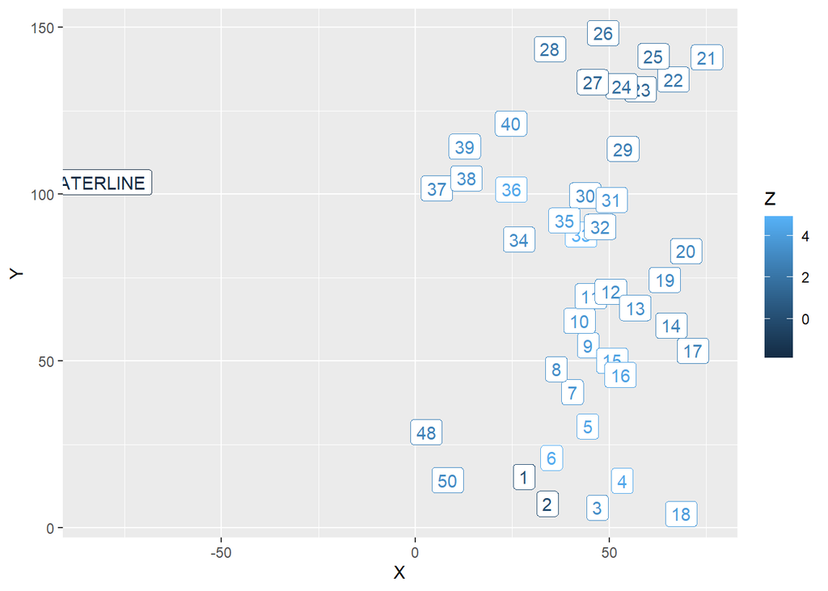

```r
ggplot(aes(x = X, y = Y, label = Plot, color = Z), data = TeMi_RelCords)+
  geom_point()+
  geom_label()
```

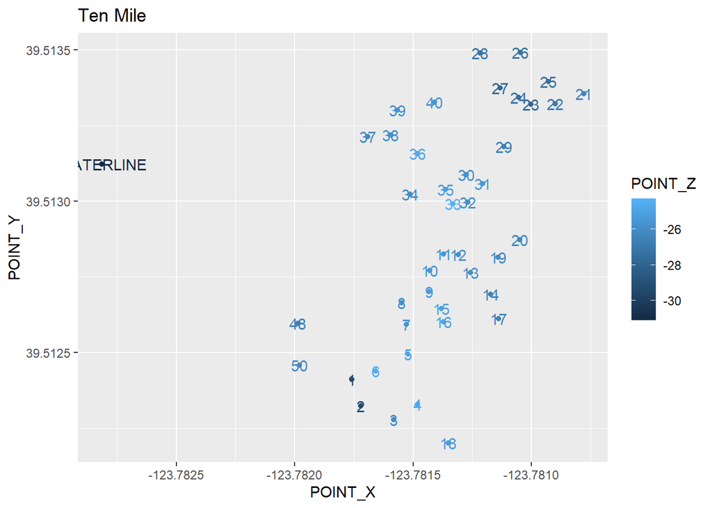

```r
ggplot(aes(x = POINT_X, y = POINT_Y, label = Comment, color = POINT_Z), data = TeMi_Locations)+
  geom_point()+
  geom_text()+
  ggtitle("Ten Mile")
```

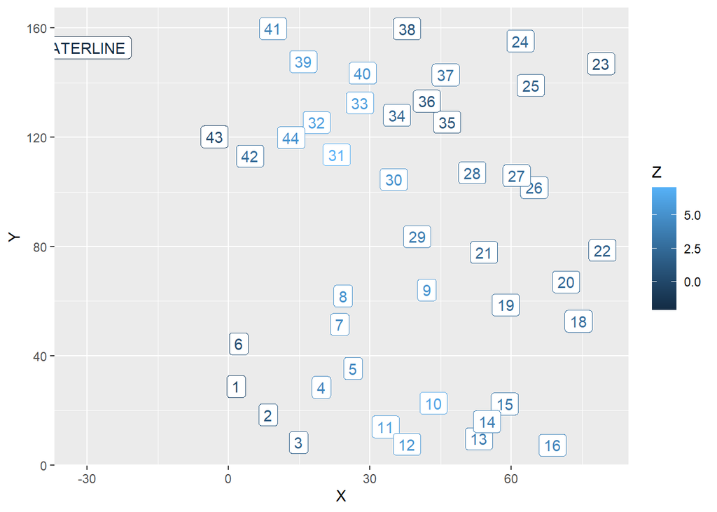

```r
ggplot(aes(x = X, y = Y, label = Plot, color = Z), data = Zmud_RelCords)+
  geom_point()+
  geom_label()
```

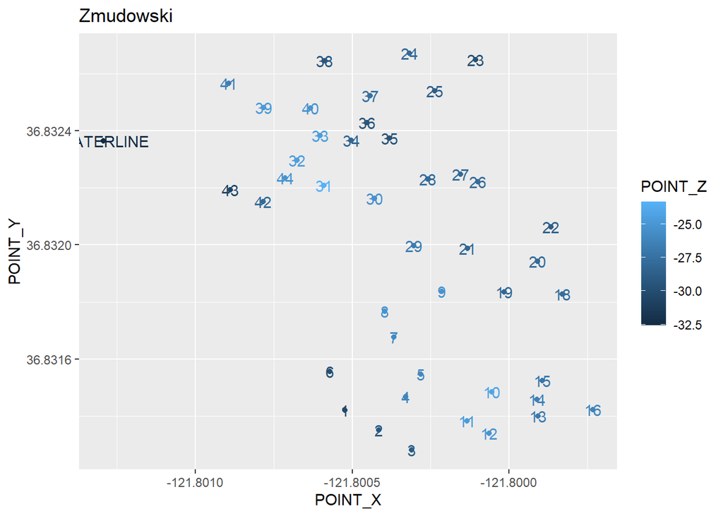

```r
ggplot(aes(x = POINT_X, y = POINT_Y, label = Comment, color = POINT_Z), data = Zmud_Locations)+
  geom_point()+
  geom_text()+
  ggtitle("Zmudowski")
```

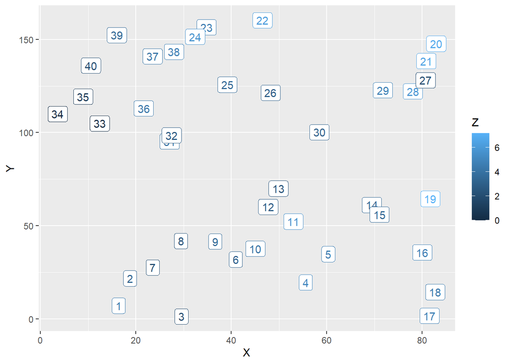

```r
ggplot(aes(x = X, y = Y, label = Plot, color = Z), data = GuNi_RelCords)+
  geom_point()+
  geom_label()
```

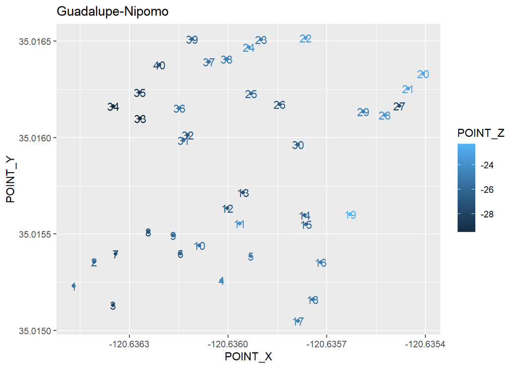

```r
ggplot(aes(x = POINT_X, y = POINT_Y, label = Comment, color = POINT_Z), data = GuNi_Locations)+
  geom_point()+
  geom_text()+
  ggtitle("Guadalupe-Nipomo")
```

# Spanning Dataframes

## Env Data

```r
DuneEnv <- read_csv(here("EnteredData", "DuneEnvData.csv"))
DuneSoil<-read_csv(here("EnteredData", "Dune_ph_salinity.csv"))
DuneEnvData<- merge(DuneEnv, DuneSoil, all = TRUE )
```

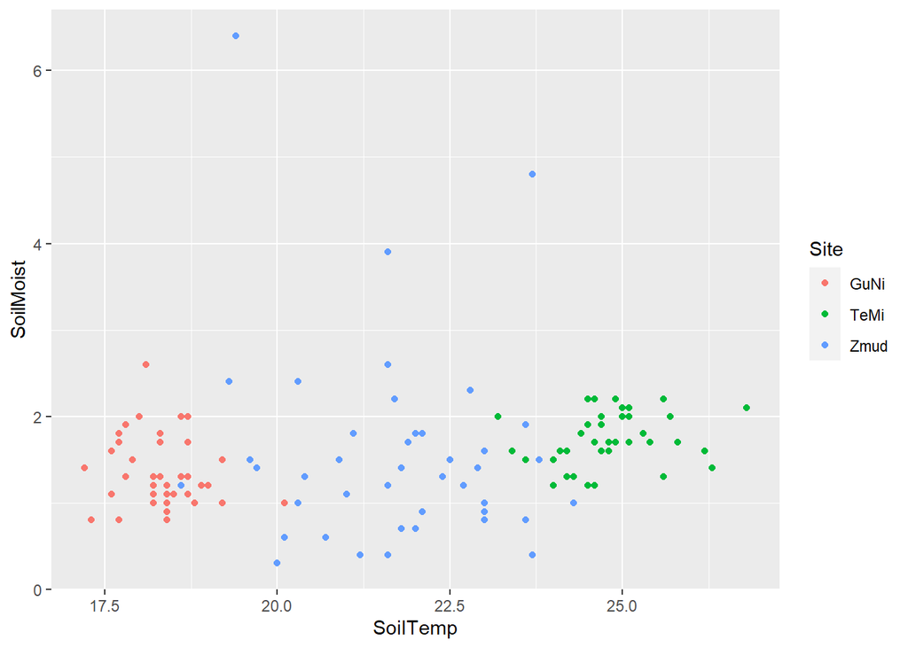

```r
ggplot(aes(x= SoilTemp, y = SoilMoist, color = Site), data = DuneEnvData)+
  geom_point() #okay so site super mattered which makes sense for temp. I'll scale it
```

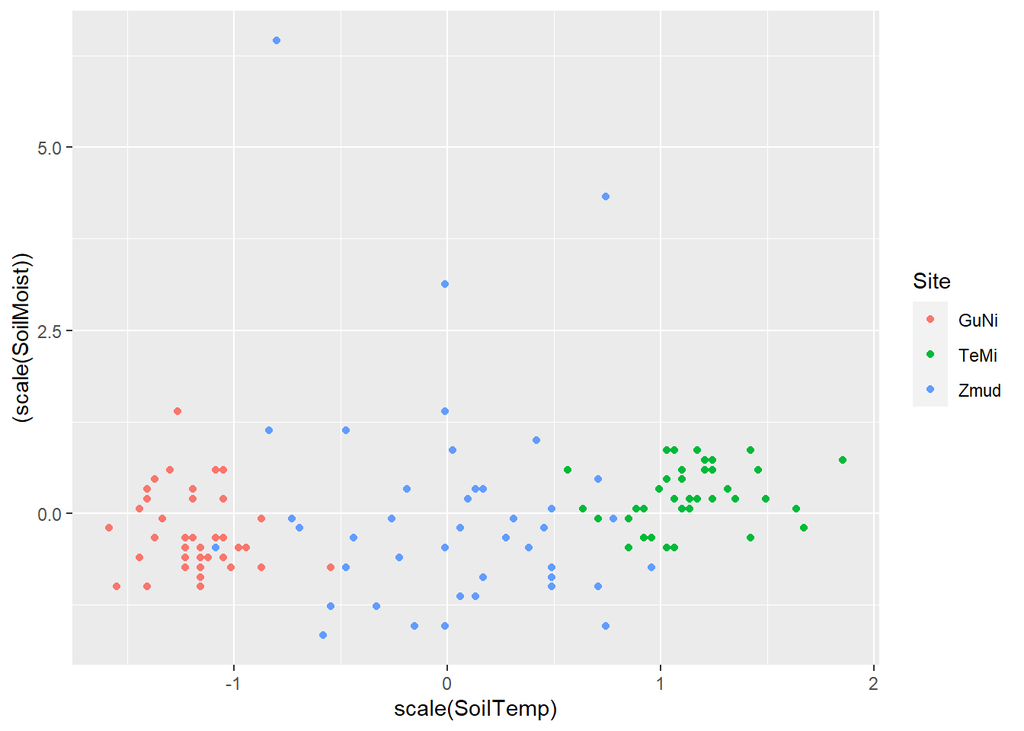

```r
ggplot(aes(x= scale(SoilTemp), y = (scale(SoilMoist)), color = Site), data = DuneEnvData)+
  geom_point() #Lol. I need to scale Soil Temp by the site! Duh! I should actually do that for Soil Moisture too but it won't be as severe
```

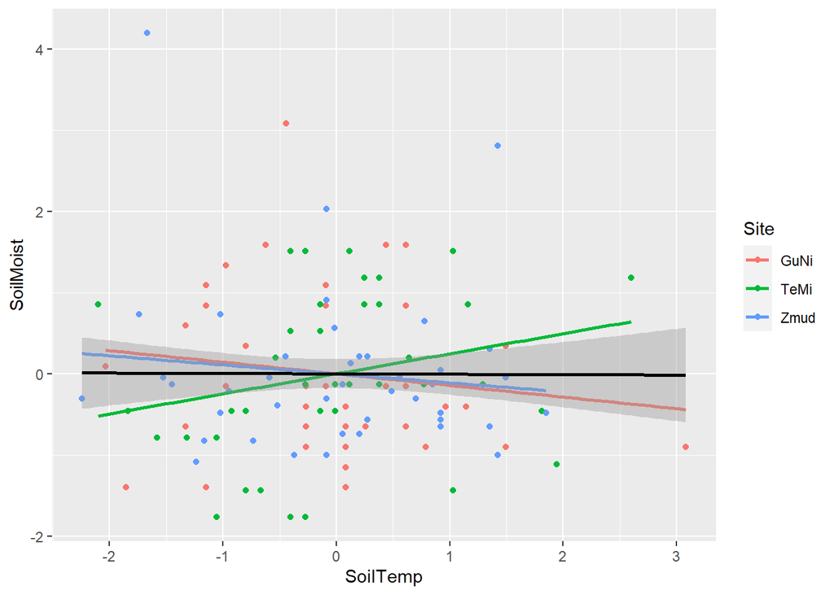

```r
#DuneEnv_scaled <- DuneEnvData %>% group_by(Site) %>% mutate(SoilTemp = scale(SoilTemp), SoilMoist=scale(SoilMoist))

DuneEnv_scaled<-plyr::ddply(DuneEnvData, "Site", transform, SoilMoist = scale(SoilMoist))

DuneEnv_scaled<-plyr::ddply(DuneEnv_scaled, "Site", transform, SoilTemp = scale(SoilTemp))

DuneEnv_scaled$SoilTemp <- DuneEnv_scaled$SoilTemp[,1]

#Temp v moist
ggplot(aes(x= SoilTemp, y = SoilMoist), data = DuneEnv_scaled)+
  geom_point(aes(color = Site)) +
  geom_smooth(method = "lm", aes(color = Site), fill = NA)+
  geom_smooth(method = "lm", color = "black")
```

```r
cor.test(x = DuneEnv_scaled$SoilMoist, y = DuneEnv_scaled$SoilTemp, method = "pearson") # temp and mositure are not correlated which is nice
```

```
##
##  Pearson's product-moment correlation
##
## data:  DuneEnv_scaled$SoilMoist and DuneEnv_scaled$SoilTemp
## t = -0.054767, df = 121, p-value = 0.9564
## alternative hypothesis: true correlation is not equal to 0
## 95 percent confidence interval:
##  -0.1818528  0.1722074
## sample estimates:
##          cor
## -0.004978767
```

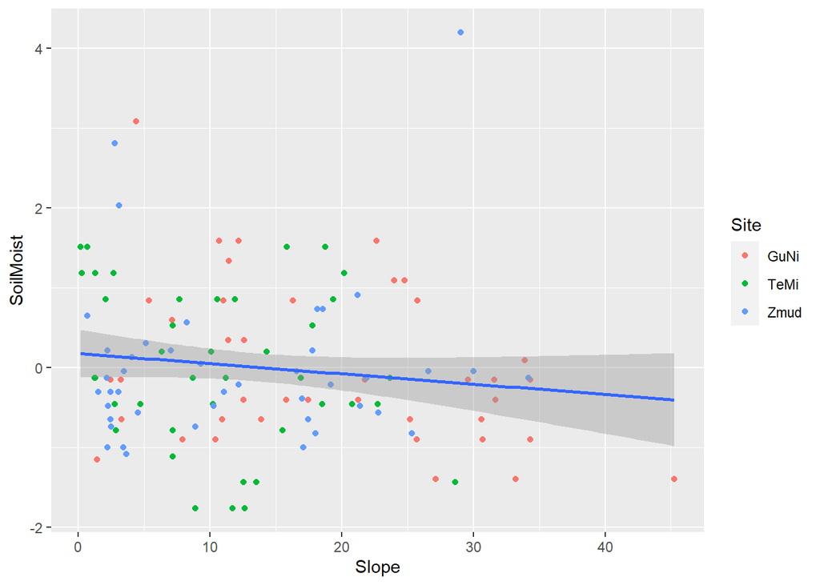

```r
# Slope v SoilMoist
ggplot(aes(x= Slope, y = SoilMoist), data = DuneEnv_scaled)+
  geom_point(aes(color = Site)) +
  geom_smooth(method = "lm")# No obvious pattern
```

```r
cor.test(x = DuneEnv_scaled$Slope, y = DuneEnv_scaled$SoilMoist, method = "pearson") # Nutthin
```

```
##
##  Pearson's product-moment correlation
##
## data:  DuneEnv_scaled$Slope and DuneEnv_scaled$SoilMoist
## t = -1.4435, df = 121, p-value = 0.1515
## alternative hypothesis: true correlation is not equal to 0
## 95 percent confidence interval:
##  -0.30022885  0.04803074
## sample estimates:
##        cor
## -0.1301099
```

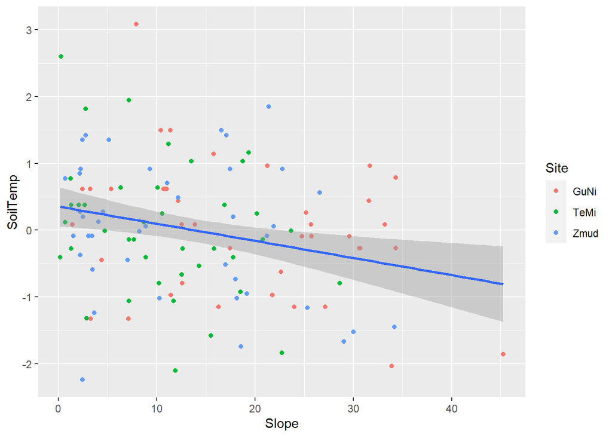

```r
#Slope v Temp ***
ggplot(aes(x= Slope , y =SoilTemp), data = DuneEnv_scaled)+
  geom_point(aes(color = Site)) +
  geom_smooth(method = "lm")
```

```r
cor.test(x = DuneEnv_scaled$Slope, y = DuneEnv_scaled$SoilTemp, method = "pearson") # Topsoil, Slope explains SoilTemp
```

```
##
##  Pearson's product-moment correlation
##
## data:  DuneEnv_scaled$Slope and DuneEnv_scaled$SoilTemp
## t = -2.9647, df = 121, p-value = 0.003651
## alternative hypothesis: true correlation is not equal to 0
## 95 percent confidence interval:
##  -0.41800607 -0.08721253
## sample estimates:
##       cor
## -0.260229
```

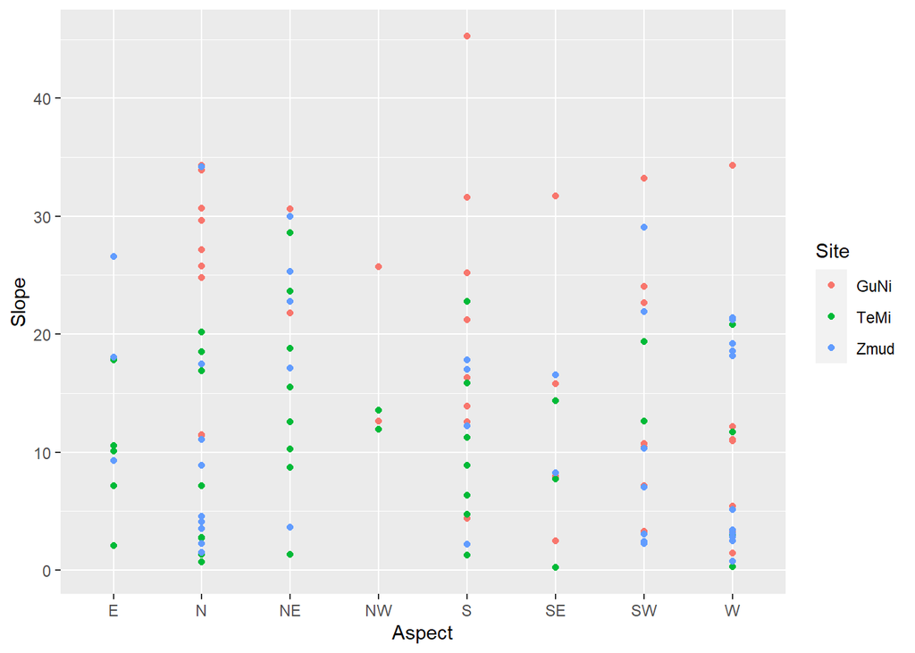

```r
#aspect slope
ggplot(aes(x= Aspect, y = Slope), data = DuneEnv_scaled)+
  geom_point(aes(color = Site)) # No obvious pattern
```

```r
summary(aov(Slope ~ Aspect, data = DuneEnv_scaled)) #nuthin
```

```
##              Df Sum Sq Mean Sq F value Pr(>F)
## Aspect        7    725   103.6   1.025  0.417
## Residuals   115  11620   101.0
```

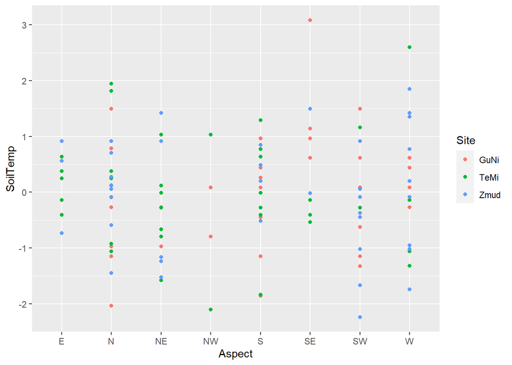

```r
#aspect temp
ggplot(aes(x= Aspect, y = SoilTemp), data = DuneEnv_scaled)+
  geom_point(aes(color = Site)) # No obvious pattern
```

```r
summary(aov(SoilTemp ~ Aspect, data = DuneEnv_scaled)) #nuthin
```

```
##              Df Sum Sq Mean Sq F value Pr(>F)
## Aspect        7  11.32   1.617   1.711  0.113
## Residuals   115 108.68   0.945
```

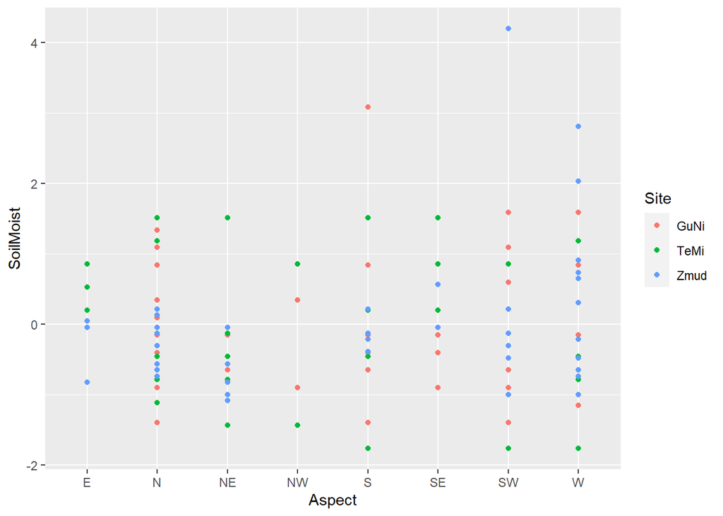

```r
#aspect Moist
ggplot(aes(x= Aspect, y = SoilMoist), data = DuneEnv_scaled)+
  geom_point(aes(color = Site)) # No obvious pattern
```

```r
summary(aov(SoilMoist ~ Aspect, data = DuneEnv_scaled)) #nuthin
```

```
##              Df Sum Sq Mean Sq F value Pr(>F)
## Aspect        7   6.04  0.8623    0.87  0.532
## Residuals   115 113.96  0.9910
```

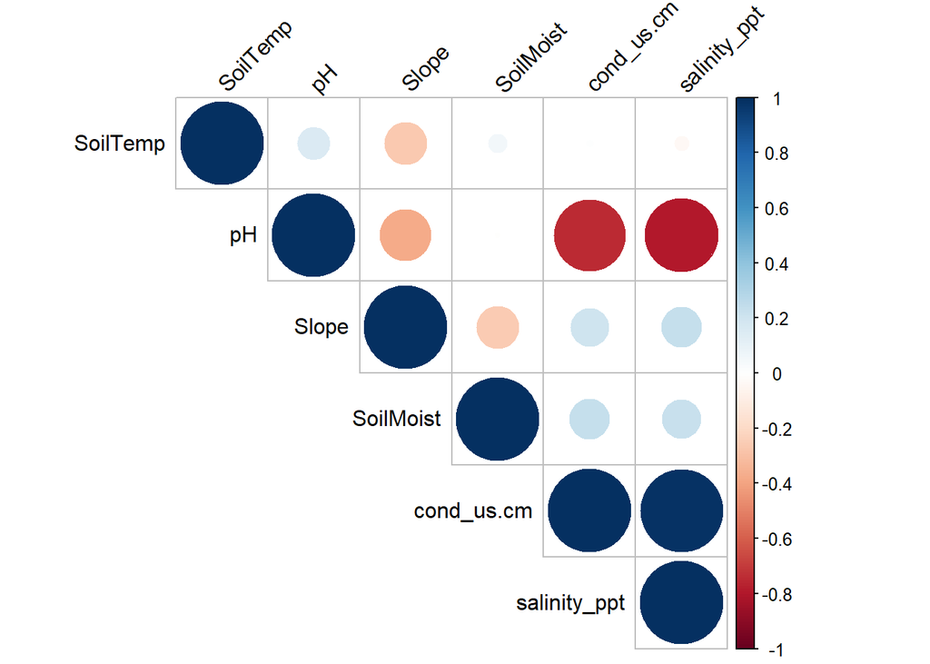

```r
DuneEnv_scaled %>%
  select(-c(Site, Plot, Aspect, Date, Collectors, dry_weight, Notes))%>%
  as.matrix()%>%
  cor(use =  "complete")%>%
  corrplot( type = "upper", order = "hclust",  tl.col = "black", tl.srt = 45)
```

## Phenology

```r
Pheno <-read_csv(here("EnteredData", "DunePhenoTrait.csv"))
head(Pheno)
```

```
## # A tibble: 6 × 9
##   Site   Plot Species        Phenology LeafLength LeafWidth LeafThickness Height
##   <chr> <dbl> <chr>          <chr>          <dbl>     <dbl>         <dbl>  <dbl>
## 1 Zmud      1 Sea Rocket     fs             30.8       7.47          2.03   89.3
## 2 Zmud      2 Yellow Sand V… v              64.2      48.2           3.69   47.7
## 3 Zmud      2 Morning glory  v              21.1      12.4           1.84   21.8
## 4 Zmud      2 Beach primrose fs              8.51      5.39          0.69   39.3
## 5 Zmud      2 Sea Rocket     s              26.8       5.92          2.64   33.6
## 6 Zmud      2 Carpobrotus e… v              38.4       8.91          7.58   57.6
## # ℹ 1 more variable: BasalDiam <dbl>
```

```r
CollectedTraits <- subset(Pheno,  is.na(LeafLength) == FALSE)


SuccTraits <- rbind(subset(CollectedTraits, Species == "Yellow Sand Verbena"), subset(CollectedTraits, Species == "Pink Sand Verbena"), subset(CollectedTraits, Species == "Purple Sand Verbena"), subset(CollectedTraits, Species == "Carpobrotus edulis"))
```

### Checking Graphs

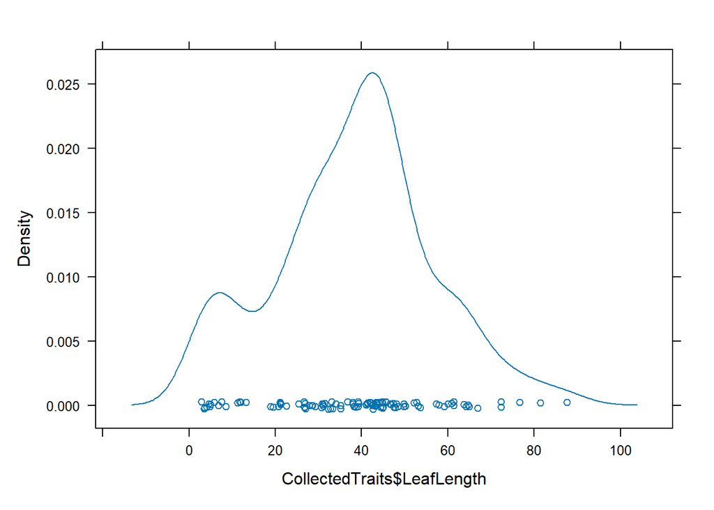

```r
densityplot(CollectedTraits$LeafLength) #Normal
```

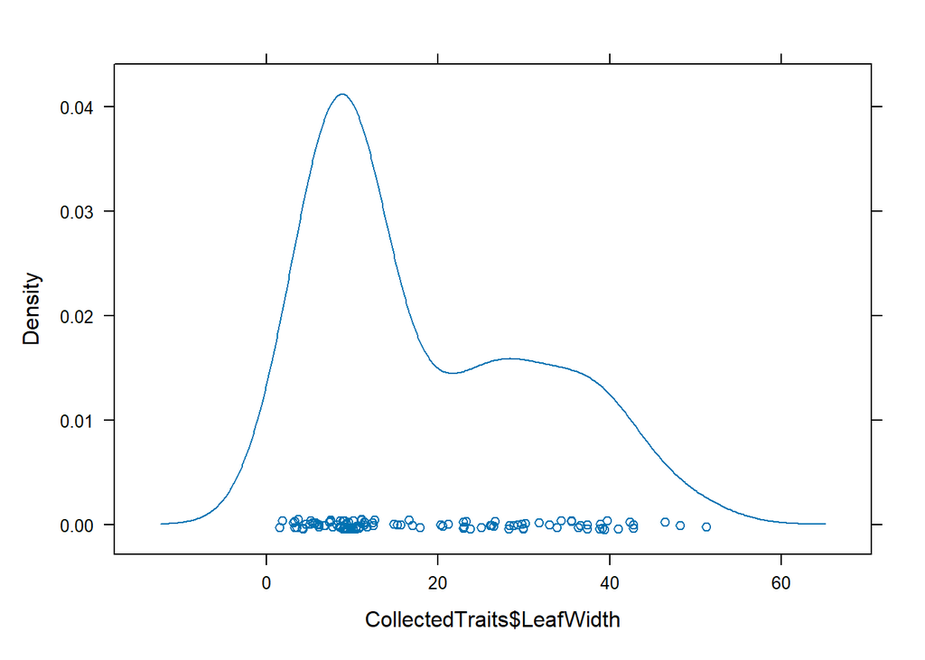

```r
densityplot(CollectedTraits$LeafWidth) #might need Log
```

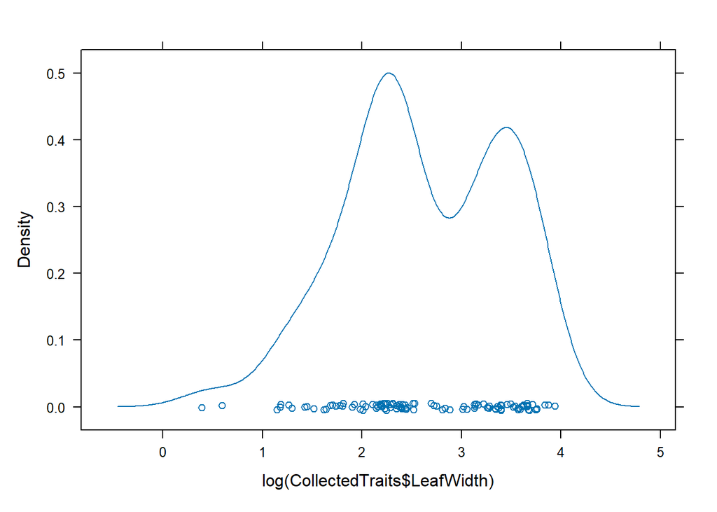

```r
densityplot(log(CollectedTraits$LeafWidth)) #not really better
```

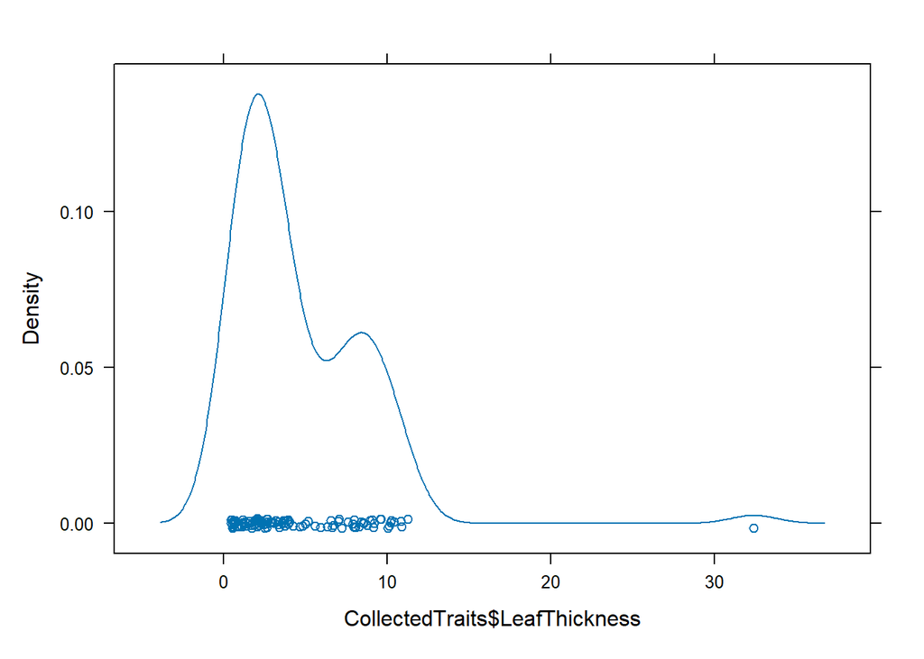

```r
densityplot(CollectedTraits$LeafThickness) #typo and log transform
```

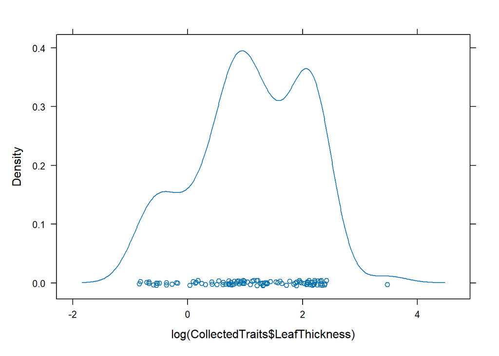

```r
densityplot(log(CollectedTraits$LeafThickness))
```

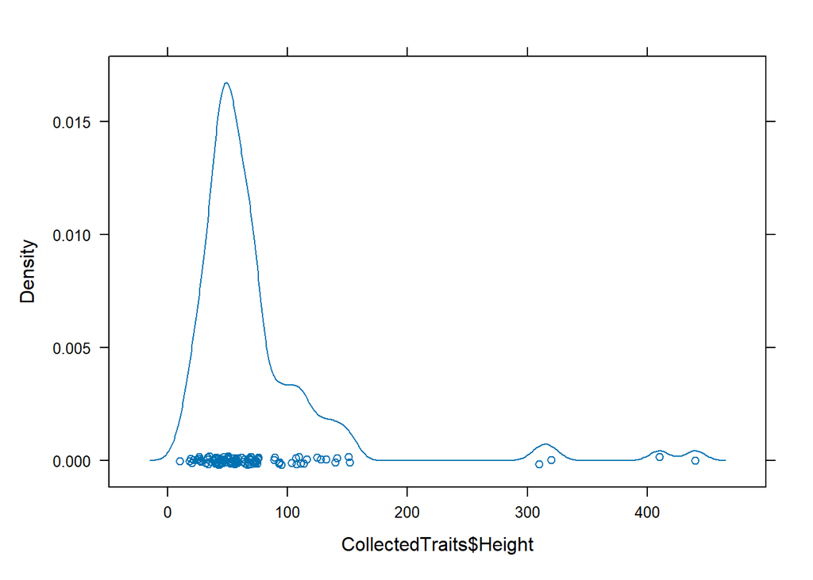

```r
densityplot(CollectedTraits$Height) #
```

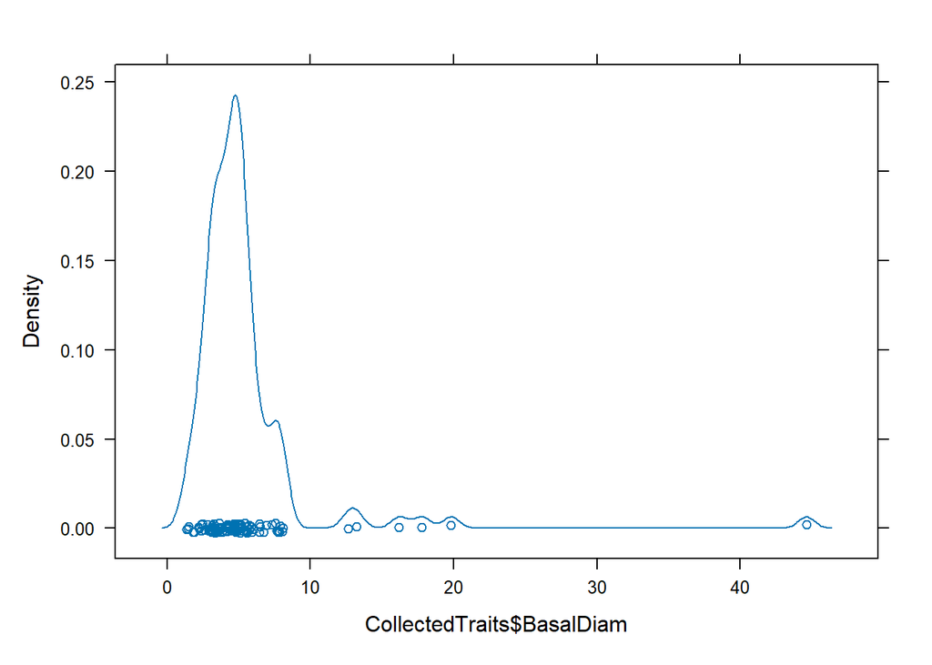

```r
densityplot(CollectedTraits$BasalDiam)
```

```r
#subset(CollectedTraits, LeafTraits$LeafThickness >20) #Thats a typo
#subset(CollectedTraits, LeafTraits$Height >205) #Okay, maybe legit
#subset(CollectedTraits, LeafTraits$BasalDiam >25) #Just a chonky boi but worth double checking
```

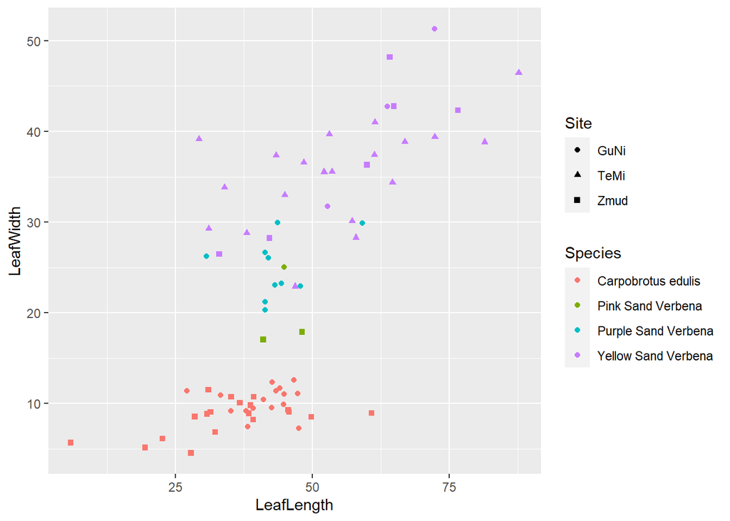

```r
ggplot(aes(x = LeafLength, y = LeafWidth, color = Species, shape = Site), data = SuccTraits)+
  geom_point()
```

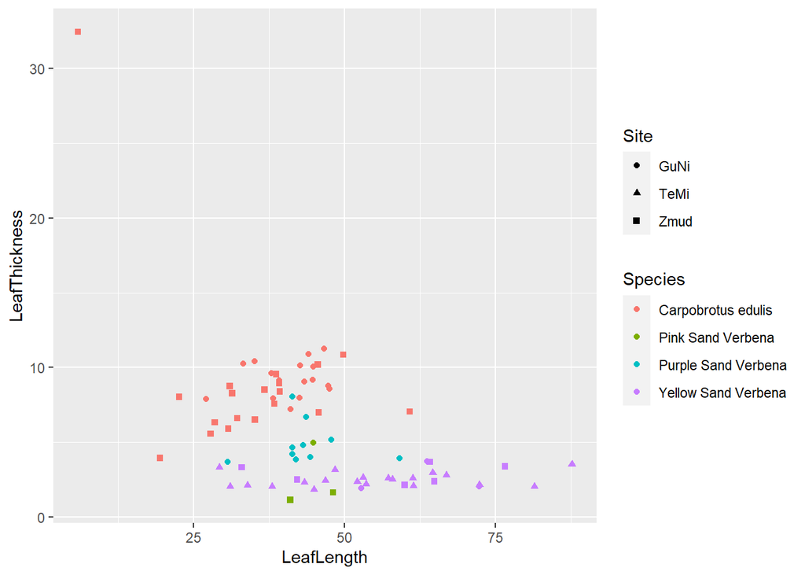

```r
ggplot(aes(x = LeafLength, y = LeafThickness, color = Species, shape = Site), data = SuccTraits)+
  geom_point()
```

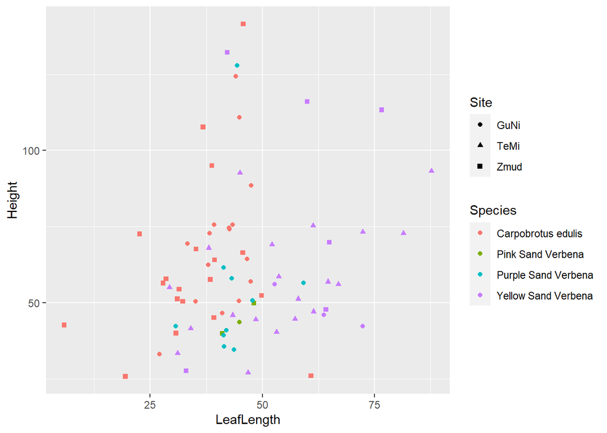

```r
ggplot(aes(x = LeafLength, y = Height, color = Species, shape = Site), data = SuccTraits)+
  geom_point()
```

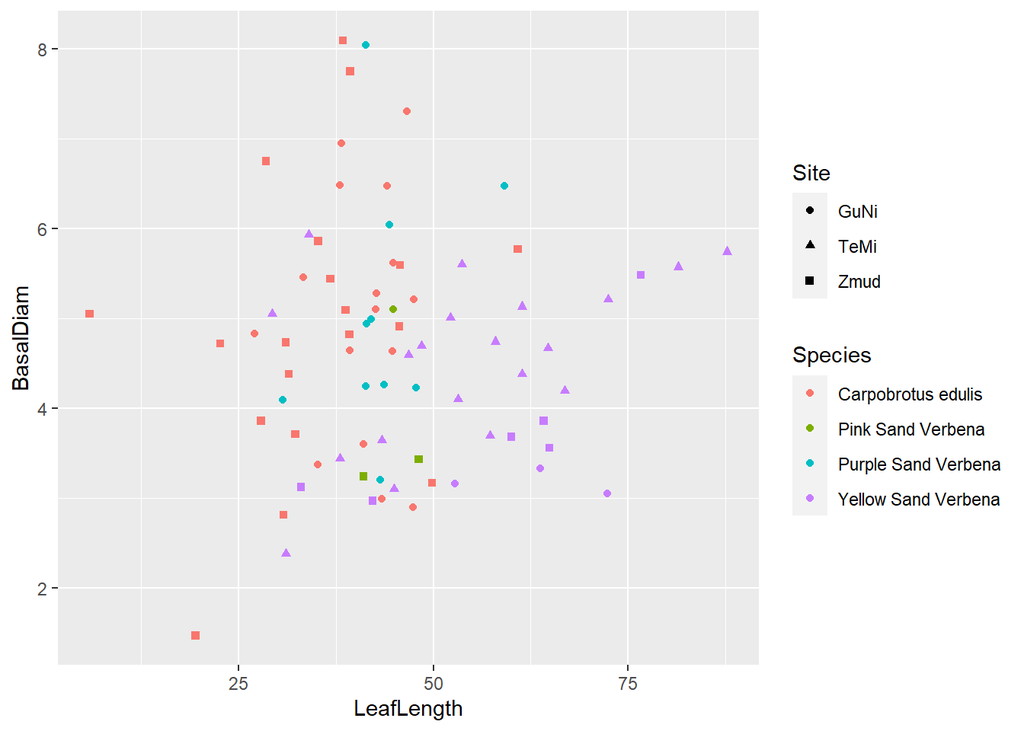

```r
ggplot(aes(x = LeafLength, y = BasalDiam, color = Species, shape = Site), data = SuccTraits)+
  geom_point()
```

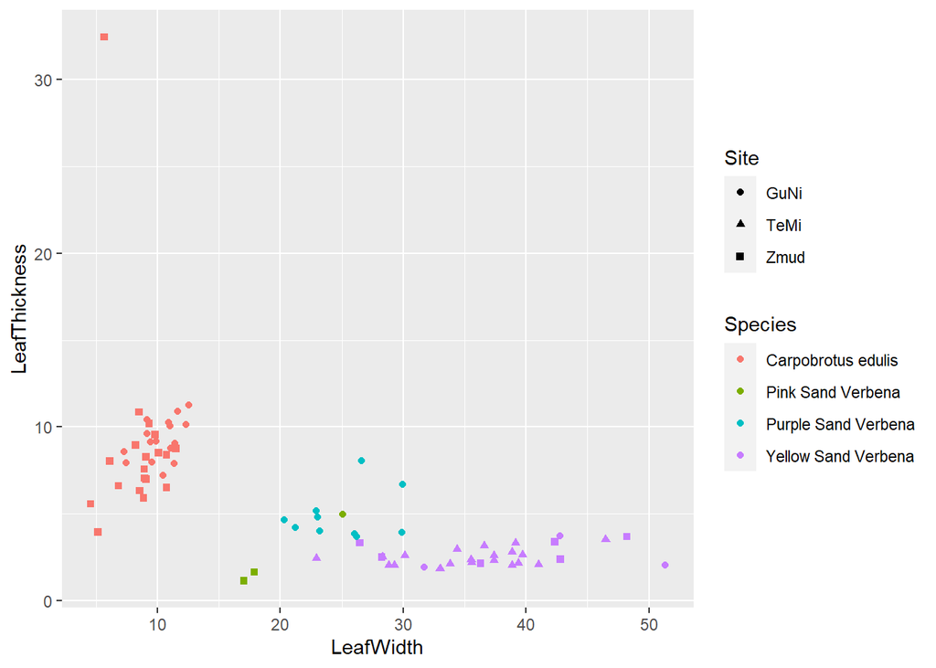

```r
ggplot(aes(x = LeafWidth, y = LeafThickness, color = Species, shape = Site), data = SuccTraits)+
  geom_point()
```

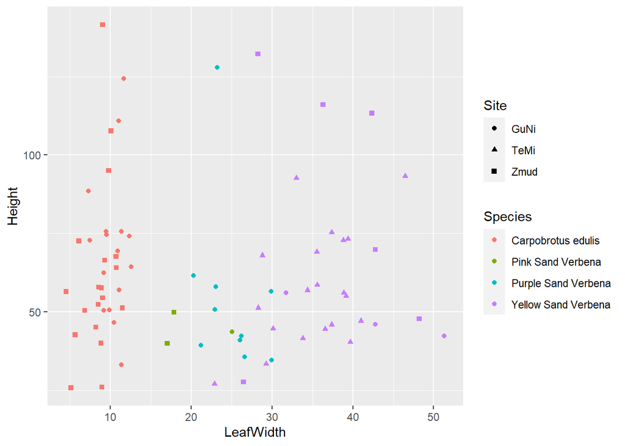

```r
ggplot(aes(x = LeafWidth, y = Height, color = Species, shape = Site), data = SuccTraits)+
  geom_point()
```

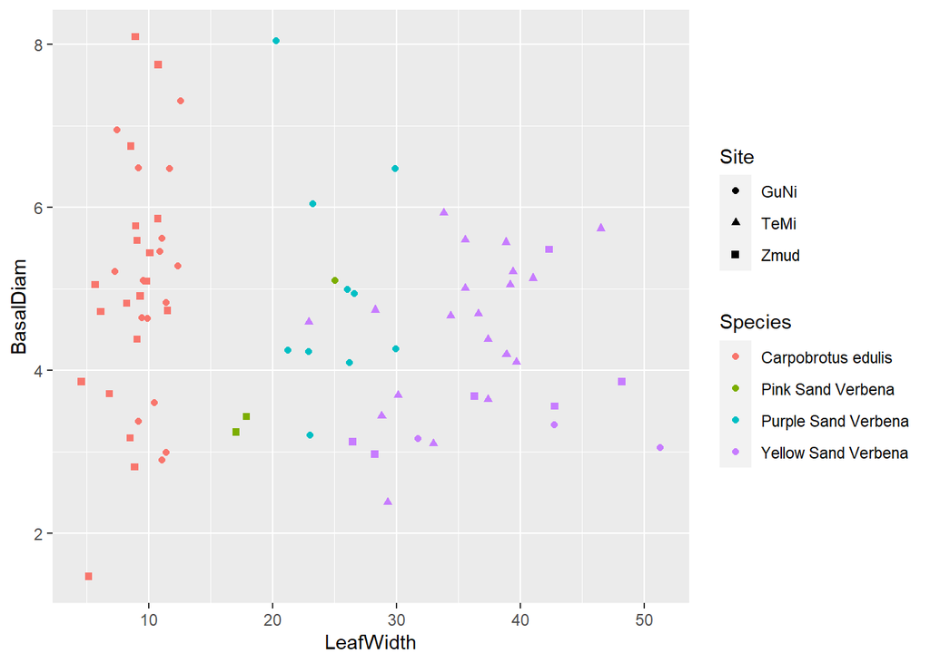

```r
ggplot(aes(x = LeafWidth, y = BasalDiam, color = Species, shape = Site), data = SuccTraits)+
  geom_point()
```

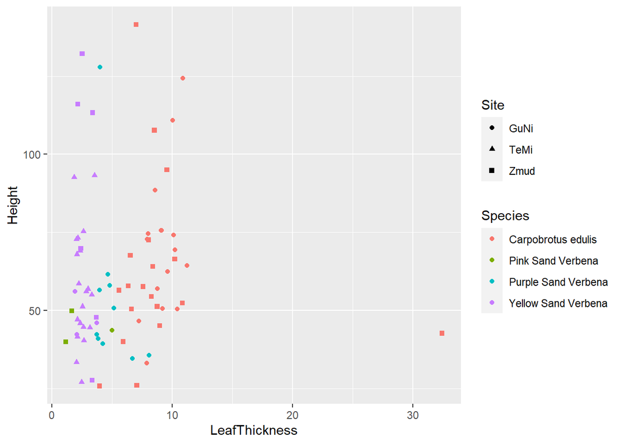

```r
ggplot(aes(x = LeafThickness, y = Height, color = Species, shape = Site), data = SuccTraits)+
  geom_point()
```

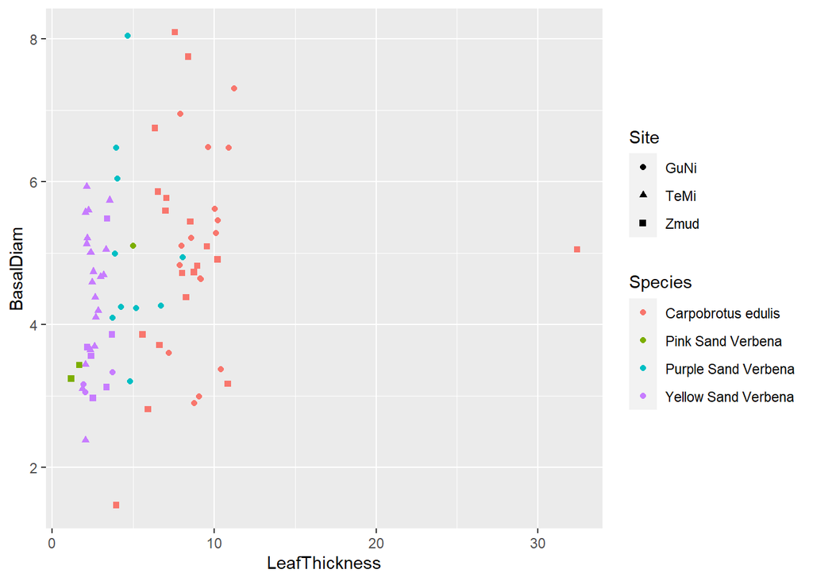

```r
ggplot(aes(x = LeafThickness, y = BasalDiam, color = Species, shape = Site), data = SuccTraits)+
  geom_point()
```

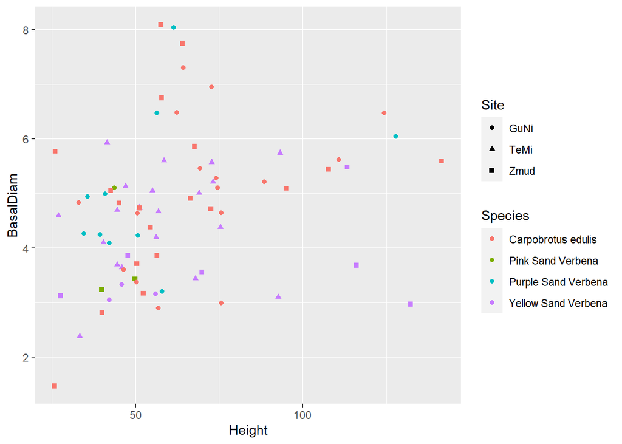

```r
ggplot(aes(x = Height, y = BasalDiam, color = Species, shape = Site), data = SuccTraits)+
  geom_point()
```

# Traits From Databases

Okay, let’s figure out how to get some traits from the online world. There is code back from the Traits textbook that I am hoping to co-op for my own purposes. I am also using this as some training for the Roots class if need be.

```r
### I moved the data set "ProperNames Up to use on Cover"

library("traits")
library("taxize")
library("TR8")
#taxa_search(Proper_Names[1:20,]$New_Species_Name, db = "traitbank")




#tr8(species_list = Proper_Names[1:5,]$New_Species_Name, gui_config=TRUE, allow_persistent=TRUE)


TryNames <- read_csv(here("EnteredData", "TryAccSpecies.csv"))
Trying<-merge(Proper_Names, TryNames, by.x ="New_Species_Name", by.y = "AccSpeciesName")

unique(Trying$AccSpeciesID)
```

```
##  [1]     79     80     82   1802   3159   3218   5228   9081   9844 211262
## [11]  10791  11145 213860  21618  22021 231771  64592  33256  34417 439646
## [21]  41396 255293
```

```r
TryTraits <- read_csv(here("EnteredData", "tde20232141444.csv"))
TryTraits$count<-rowSums(TryTraits[3:length(TryTraits)] != 0)

PickedTraits<- subset(TryTraits, count>5)

colSums(PickedTraits[3:length(TryTraits)] != 0)
```

```
##                  .Abronia latifolia.                   .Abronia maritima.
##                                   13                                   15
##                  .Abronia umbellata.               .Agoseris apargioides.
##                                   13                                    9
##               .Ambrosia chamissonis.                 .Ammophila arenaria.
##                                    9                                   20
##             .Artemisia pycnocephala.                    .Cakile maritima.
##                                   12                                   20
##              .Calystegia soldanella.     .Camissoniopsis cheiranthifolia.
##                                   18                                   12
##                 .Carpobrotus edulis.               .Castilleja latifolia.
##                                   18                                   10
##                .Chorizanthe pungens.               .Ericameria ericoides.
##                                    3                                   17
##                 .Erysimum menziesii. .Grindelia stricta var. platyphylla.
##                                    9                                    3
##                .Lathyrus littoralis.                      .Leymus mollis.
##                                   12                                   13
##                   .Lupinus arboreus.                                count
##                                   19                                   21
```

```r
PickedTraits$TraitID
```

```
##  [1]   28   17   43  759   22   42 3401 3400 3106  604   38   26  822   59    8
## [16] 1254 3114 3117  154   95   31
```